# Publication figure report

none

manual

**Important**

A manual command generated this report without an LLM model. No separate human scientific review is part of this fixed recipe. The report records the selected recipe and does not claim a new statistical method.

## Figure

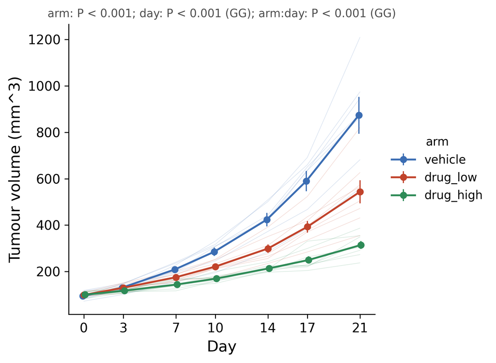

Publication figure

## Statistical results

| effect | ss | df1 | df2 | F | p_value | gg_epsilon | p_gg | correction | p_reported | partial_eta2 |
| --- | --- | --- | --- | --- | --- | --- | --- | --- | --- | --- |
| arm | 897610.2426053688 | 2 | 20 | 28.430557453102654 | 1.4230925938205912e-06 |  |  | none | 1.4230925938205912e-06 | 0.7397903995485067 |
| day | 3844692.837391304 | 6 | 120 | 236.19920299127807 | 5.6810913970117326e-64 | 0.19512909918966329 | 2.607148307060976e-14 | Greenhouse-Geisser | 2.607148307060976e-14 | 0.9219357446608416 |
| arm:day | 938415.5118433889 | 12 | 120 | 28.825839325366815 | 8.619432333776584e-30 | 0.19512909918966329 | 2.0039733609649322e-07 | Greenhouse-Geisser | 2.0039733609649322e-07 | 0.7424395666968489 |

## Methods

Tumour volume (mm^3) was analysed with a mixed ANOVA with the group as a between-subjects factor and time as a within-subjects factor (n = 23 subjects, 7 time points). 1 subject(s) without a value at every time point were excluded. Sphericity was assessed with Mauchly’s test (W = 0.000, P = 2.1e-37); because it was rejected, the within-subject effects carry the Greenhouse-Geisser correction (epsilon = 0.195). arm, F(2, 20) = 28.43, P < 0.001, partial eta squared = 0.740; day, F(1.17, 23.42) = 236.20, P < 0.001, partial eta squared = 0.922; arm:day, F(2.34, 23.42) = 28.83, P < 0.001, partial eta squared = 0.742. The figure shows the mean +/- SEM at each time point, with one thin line per subject. Computed in Python 3.10.12 with numpy 1.26.4 and scipy 1.15.3, and drawn with matplotlib 3.10.9.

## Plot configuration

The complete plot configuration is in `plot_config.yaml`.

## Provenance

[output not shown]

The report source reads only files in this bundle.